# 06-Analyzing MACAU results-rev

Laura H Spencer

9/12/2019

## MACAU results - visualize and FDR correct

Ran MACAU in a Jupyter Notebook. See 05-MACAU.ipynb

In this notebook I assess patterns in methylated loci that MACAU identified as influence by oyster phenotype, aka oyster shell length.

#### Load libraries

```r
list.of.packages <- c("vegan", "dplyr", "factoextra", "FactoMineR", "tidyverse", "tibble", "reshape2", "gplots", "qvalue", "cluster") #add new libraries here
new.packages <- list.of.packages[!(list.of.packages %in% installed.packages()[,"Package"])]
if(length(new.packages)) install.packages(new.packages)

# Load all libraries
lapply(list.of.packages, FUN = function(X) {
  do.call("require", list(X))
})
source("../resources/biostats.R")
```

#### Read in dataframe with MACAU assocation results

```r
macau.20190812 <- read.table(file="../analyses/macau/output/20190812-macau.assoc.txt", sep = "\t", stringsAsFactors = F)
head(macau.20190812)
```

```
##             V1 V2        V3         V4        V5        V6        V7
## 1           id  n acpt_rate       beta   se_beta    pvalue         h
## 2 Contig038973 18 4.069e-01 -6.949e-02 5.548e-02 2.104e-01 7.713e-01
## 3 Contig039226 18 4.844e-01 -1.022e-02 3.708e-02 7.829e-01 6.961e-01
## 4 Contig039234 18 3.831e-01  4.603e-02 3.661e-02 2.087e-01 7.543e-01
## 5 Contig039252 18 4.388e-01 -4.211e-02 5.445e-02 4.393e-01 7.156e-01
## 6 Contig041234 18 3.909e-01  7.483e-02 9.470e-02 4.294e-01 6.285e-01
##          V8        V9       V10        V11       V12        V13       V14
## 1      se_h    sigma2 se_sigma2     alpha0 se_alpha0     alpha1 se_alpha1
## 2 2.336e-01 2.793e+00 5.452e+00  1.936e+00 1.027e+00  4.199e-01 2.701e-01
## 3 2.519e-01 9.479e-01 1.905e+00  8.591e-01 6.584e-01 -2.180e-01 1.730e-01
## 4 2.308e-01 3.532e+00 1.117e+01 -1.400e+00 7.399e-01 -1.432e-01 1.573e-01
## 5 2.512e-01 3.239e+00 8.253e+00  1.283e+00 1.019e+00  1.868e-01 2.675e-01
## 6 2.689e-01 5.002e+00 8.564e+00  4.363e-01 1.708e+00 -4.537e-01 3.745e-01
```

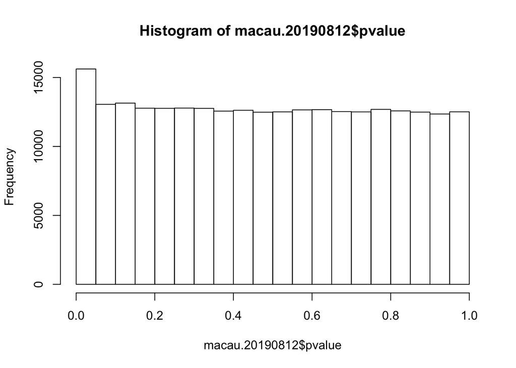

```r
colnames(macau.20190812) <- macau.20190812[1,]
macau.20190812 <- macau.20190812[-1, ]
macau.20190812$pvalue <- as.numeric(macau.20190812$pvalue)
hist(macau.20190812$pvalue)
```

```r
tail(macau.20190812)
```

```
##                     id  n acpt_rate       beta   se_beta  pvalue         h
## 256039 Contig999686327 18 2.867e-01 -7.455e-02 1.685e-01 0.65820 4.446e-01
## 256040 Contig999686331 18 2.667e-01  2.807e-03 6.758e-02 0.96690 7.291e-01
## 256041 Contig999686335 18 2.837e-01  1.930e-01 1.060e-01 0.06853 6.724e-01
## 256042 Contig999686355 18 3.135e-01 -2.182e-01 1.371e-01 0.11150 7.448e-01
## 256043 Contig999686427 18 3.417e-01 -9.610e-02 1.251e-01 0.44250 3.734e-01
## 256044 Contig999924037 18 2.297e-01  9.472e-02 6.431e-02 0.14080 7.273e-01
##             se_h    sigma2 se_sigma2     alpha0 se_alpha0     alpha1
## 256039 1.970e-01 1.469e+01 1.571e+01  5.009e+00 3.466e+00  3.400e-01
## 256040 2.308e-01 5.274e+00 1.207e+01  2.761e+00 1.356e+00  1.124e-02
## 256041 2.738e-01 8.602e+00 1.410e+01  5.117e-01 1.757e+00 -3.651e-01
## 256042 2.632e-01 9.999e+00 1.805e+01  7.327e+00 2.813e+00  8.290e-01
## 256043 2.260e-01 5.672e+00 5.909e+00  6.830e-01 2.057e+00  5.862e-01
## 256044 1.666e-01 6.692e+00 7.840e+00 -1.337e+00 1.218e+00 -3.824e-01
##        se_alpha1
## 256039 7.843e-01
## 256040 2.735e-01
## 256041 4.128e-01
## 256042 6.921e-01
## 256043 5.910e-01
## 256044 2.708e-01
```

#### Correct for multiple comparisons

From Mac’s 2019 salmon paper, doi:10.3390/genes10050356  
“Multiple hypothesis testing was performed on P-values extracted from the MACAU output for each CG site using the false discovery rate (FDR) approach used in the R package qvalue [45]. We considered a CG site to be differentially methylated (i.e., differentially methylated cytosine (DMC) if it passed a 10% FDR threshold, consistent with [46].”

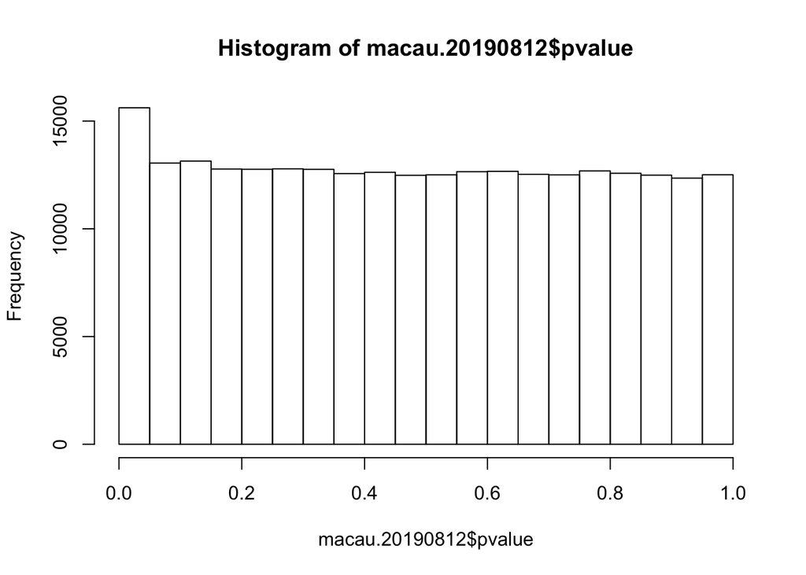

```r
hist(macau.20190812$pvalue) # p-value distribution looks good (i.e. not u-shaped)
```

```r
macau.qvalue <- qvalue(p = macau.20190812$pvalue, fdr.level = 0.1) # create qvalue object, setting FDR=10%
summary(macau.qvalue)
```

```
##
## Call:
## qvalue(p = macau.20190812$pvalue, fdr.level = 0.1)
##
## pi0: 0.9745183
##
## Cumulative number of significant calls:
##
##           <1e-04 <0.001 <0.01 <0.025 <0.05  <0.1     <1
## p-value      233    849  4226   8732 15616 28662 256028
## q-value        1      7    22     54   111   219 256043
## local FDR      0      4    12     24    50   121 113358
```

```r
100*(1- macau.qvalue$pi0) #% of all loci in df as truely sign.
```

```
## [1] 2.548171
```

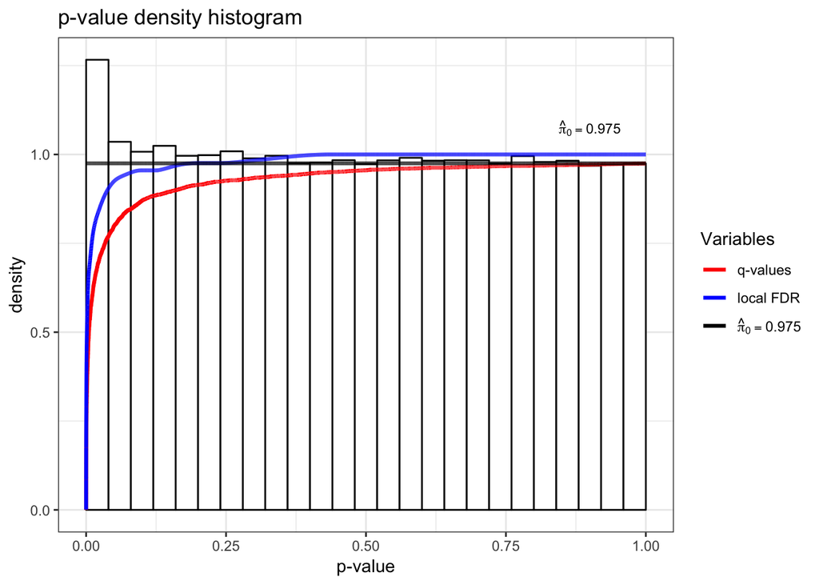

```r
hist(macau.qvalue)
```

```r
#if one wants to estimate the false discovery rate when calling all p-values ≤ 0.01 significant:
max(macau.qvalue$qvalues[macau.qvalue$pvalues <= 0.01])
```

```
## [1] 0.5900381
```

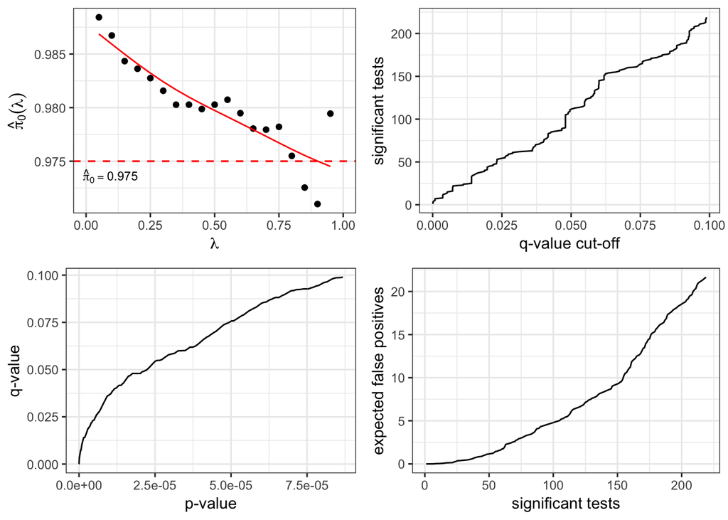

```r
# The main purpose of the upper-left plot is to gauge the reliability of the π0 estimate, where the estimated π0 is plotted versus the tuning parameter λ. The remaining plots show how many tests are significant, as well as how many false positives to expect for each q-value cut-off.
plot(macau.qvalue)
```

```r
# Given our FDR=10% level, how many are significant?
summary(macau.qvalue$significant) #219 sign. (# TRUE)
```

```
##    Mode   FALSE    TRUE
## logical  255824     219
```

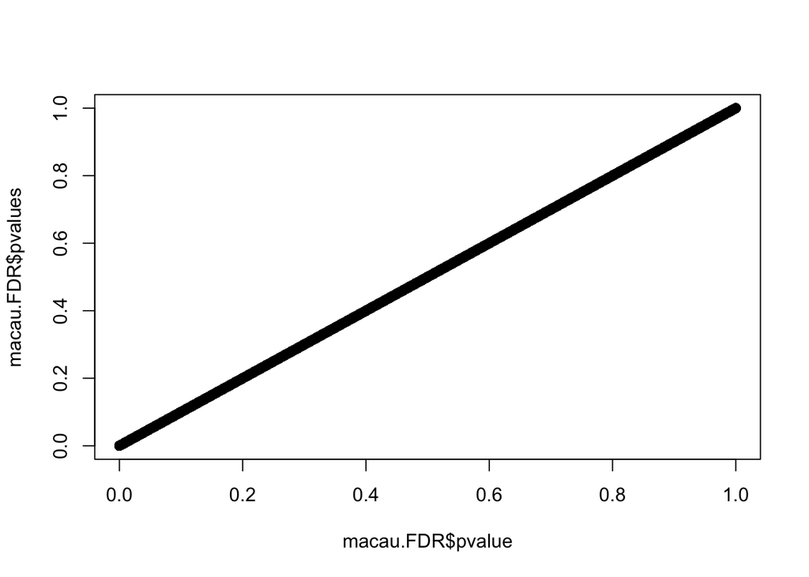

```r
# Add qvalue results to macau df
macau.FDR <- cbind(macau.20190812, do.call(cbind.data.frame, macau.qvalue[c("qvalues", "pvalues", "significant")]))

#plot macau p-values against pvalues in the qvalue results - should all fall on 1:1 line (double check that pvalues are in same order) -
plot(macau.FDR$pvalue, macau.FDR$pvalues) # looks good!
```

#### Extract IDs for loci where MACAU indicates DML, FDR test (at 10%) deemed loci significantt

```r
head(macau.sign <- subset(macau.FDR, significant=="TRUE"), n=20)
```

```
##                      id  n acpt_rate       beta   se_beta    pvalue
## 5843   Contig1054173286 18 2.926e-01  4.986e-01 1.054e-01 2.237e-06
## 9215    Contig109628199 18 2.832e-01  4.911e-01 1.216e-01 5.387e-05
## 9851   Contig1102783989 18 2.859e-01  5.282e-01 1.201e-01 1.098e-05
## 10312   Contig110906429 18 2.612e-01  3.133e-01 6.290e-02 6.351e-07
## 10342   Contig110927764 18 2.641e-01  3.686e-01 8.833e-02 3.001e-05
## 10982   Contig111772433 18 2.891e-01 -4.404e-01 1.012e-01 1.355e-05
## 11071  Contig1118734850 18 2.512e-01  6.613e-01 1.548e-01 1.929e-05
## 11956  Contig1129975372 18 2.600e-01 -3.496e-01 8.085e-02 1.534e-05
## 11970    Contig11310801 18 2.104e-01  7.822e-01 1.861e-01 2.630e-05
## 12204   Contig113403874 18 3.295e-01  3.111e-01 7.252e-02 1.790e-05
## 12337  Contig1135681836 18 3.255e-01 -7.990e-01 1.910e-01 2.886e-05
## 12379   Contig113675119 18 2.322e-01 -5.866e-01 1.423e-01 3.745e-05
## 13832   Contig117443800 18 2.785e-01  1.751e+00 3.729e-01 2.645e-06
## 15575   Contig120547984 18 3.502e-01 -2.134e-01 5.066e-02 2.512e-05
```

[output cut: 48 more lines]

#### Read in count data

Use dataframe that has the siteID, and original contig, start #, and end # info

```r
head(meth.destranded.df <- read.table(file = "../analyses/meth.destranded.df.txt", sep = "\t", header=T, stringsAsFactors = F))
```

```
##         siteID     chr start   end strand coverage1 numCs1 numTs1
## 1 Contig038973 Contig0 38973 38973      +        15     13      2
## 2 Contig039226 Contig0 39226 39226      +        21     11     10
## 3 Contig039234 Contig0 39234 39234      +        24     10     14
## 4 Contig039252 Contig0 39252 39252      +        13      9      4
## 5 Contig041234 Contig0 41234 41234      +         4      3      1
## 6 Contig064124 Contig0 64124 64124      +         5      2      3
##   coverage2 numCs2 numTs2 coverage3 numCs3 numTs3 coverage4 numCs4 numTs4
## 1        16     15      1        16     13      3        13     10      3
## 2        22     17      5        22     10     12        23     14      9
## 3        27      7     20        27     10     17        26      5     21
## 4        11      8      3        11      6      5        12      9      3
## 5         4      3      1         7      5      2        10     10      0
## 6         8      2      6         7      4      3        10      9      1
##   coverage5 numCs5 numTs5 coverage6 numCs6 numTs6 coverage7 numCs7 numTs7
```

[output cut: 41 more lines]

```r
#counts.tot.destrand <- read.table(file = "../analyses/counts-total-destrand.txt", header = T)
#counts.meth.destrand <- read.table(file = "../analyses/counts-meth-destrand.txt", header = T)
```

#### Merge MACAU + FDR results with raw count data

**This constitutes a master dataframe**

```r
# merge macau results with count dataframe, save to file
head(macau.sign.counts <- merge(x=macau.sign, y=subset(meth.destranded.df, siteID %in% macau.sign$id), by.x="id", by.y="siteID"))
```

```
##                 id  n acpt_rate       beta   se_beta    pvalue         h
## 1 Contig1054173286 18 2.926e-01  4.986e-01 1.054e-01 2.237e-06 7.040e-01
## 2  Contig109628199 18 2.832e-01  4.911e-01 1.216e-01 5.387e-05 7.224e-01
## 3 Contig1102783989 18 2.859e-01  5.282e-01 1.201e-01 1.098e-05 7.375e-01
## 4  Contig110906429 18 2.612e-01  3.133e-01 6.290e-02 6.351e-07 7.652e-01
## 5  Contig110927764 18 2.641e-01  3.686e-01 8.833e-02 3.001e-05 7.198e-01
## 6  Contig111772433 18 2.891e-01 -4.404e-01 1.012e-01 1.355e-05 7.636e-01
##        se_h    sigma2 se_sigma2     alpha0 se_alpha0     alpha1 se_alpha1
## 1 2.439e-01 7.871e+00 1.225e+01 -3.424e+00 2.191e+00 -1.542e+00 4.904e-01
## 2 2.429e-01 1.071e+01 1.657e+01 -6.054e+00 2.291e+00 -3.527e-01 6.728e-01
## 3 2.446e-01 8.995e+00 1.343e+01 -4.223e+00 2.274e+00 -1.286e+00 4.032e-01
## 4 2.335e-01 1.004e+01 1.669e+01 -1.510e+00 1.214e+00 -9.761e-01 2.726e-01
## 5 2.510e-01 9.976e+00 1.544e+01 -2.992e+00 1.735e+00 -1.055e+00 3.935e-01
## 6 2.278e-01 7.196e+00 1.415e+01  7.664e+00 1.741e+00  2.855e+00 5.831e-01
##       qvalues   pvalues significant          chr start   end strand
```

[output cut: 55 more lines]

```r
write.table(macau.sign.counts, file = "../analyses/combined-macau-FDR-counts.txt", sep = "\t", row.names = FALSE,  quote = FALSE)
```

#### Pull out separate methylation count & coverage count dfs

```r
macau.sign.tot.counts <- macau.sign.counts[, !(grepl("num", colnames(macau.sign.counts)))]
macau.sign.meth.counts <- macau.sign.counts[, !(grepl("numT|coverage", colnames(macau.sign.counts)))]
```

```r
macau.sign.tot.counts.5x <- macau.sign.tot.counts %>%
  mutate_at(vars(contains('coverage')), funs(ifelse(. < 4, NA, .)))
```

#### Create % methylated dataframe with sign. MACAU loci

```r
# duplicate macau methylated count dataframe to make % methylated df for 5x coverage (all <5x cov will be "NA"")
macau.sign.perc.meth.5x <- macau.sign.meth.counts

# divide macau methylated counts by total counts
macau.sign.perc.meth.5x[,22:39] <- 100*(macau.sign.meth.counts[,22:39]/macau.sign.tot.counts.5x[,22:39])
head(macau.sign.perc.meth.5x[22:39])
```

```
##      numCs1    numCs2    numCs3    numCs4    numCs5 numCs6    numCs7
## 1  87.50000 100.00000 100.00000 100.00000 100.00000 100.00 100.00000
## 2  81.81818  90.00000 100.00000 100.00000 100.00000 100.00  92.30769
## 3  88.88889 100.00000 100.00000 100.00000 100.00000 100.00  91.66667
## 4  76.92308  93.10345 100.00000  96.77419 100.00000  93.75  93.54839
## 5  40.00000  94.11765  92.30769 100.00000 100.00000 100.00  84.61538
## 6 100.00000  93.75000  92.85714  93.75000  83.33333  87.50  94.11765
##      numCs8    numCs9   numCs10   numCs11   numCs12   numCs13 numCs14
## 1  90.00000  93.75000 100.00000 100.00000  88.88889 100.00000     100
## 2 100.00000  75.00000 100.00000 100.00000 100.00000 100.00000     100
## 3 100.00000  93.33333  94.11765        NA  92.85714 100.00000      90
## 4 100.00000  90.47619  95.00000  97.05882 100.00000  96.55172     100
## 5  68.42105  88.88889 100.00000 100.00000  90.00000  93.75000     100
## 6 100.00000 100.00000 100.00000 100.00000  90.90909  95.23810     100
##   numCs15   numCs16   numCs17   numCs18
## 1     100 100.00000 100.00000  85.71429
## 2     100 100.00000  90.90909 100.00000
## 3     100 100.00000 100.00000  93.75000
## 4     100  96.96970  94.28571  91.66667
## 5     100  87.50000 100.00000  87.50000
## 6      88  95.45455  94.73684 100.00000
```

```r
rownames(macau.sign.perc.meth.5x) <- macau.sign.perc.meth.5x[,1]
```

—> mbd samples #1-9 = Hood Canal population  
—> mbd samples #10-18 = South Sound population

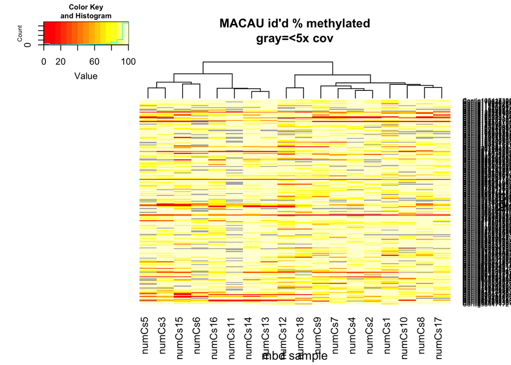

```r
par(cex.main=.8)
heatmap.2(as.matrix(macau.sign.perc.meth.5x[22:39]), main = "MACAU id'd % methylated\ngray=<5x cov", xlab = "mbd sample", ylab = "loci", na.color = "gray70", hclustfun = function(x) hclust(x, method="ward.D"), distfunc <- function(x) daisy(x,metric="gowers"), trace="none", dendrogram = "column" )
```

#### Prepare size data to plot in same order as this heat map

This is laborious code with some room for error - needs fixing

```r
size <- read.csv(file = "../data/mbd_size.csv", header=T, sep = "\t")
key <- read.csv("../data/sample-key.csv")
size.macau <- cbind(x=c(rep(1,times=18)), y=merge(y=size, x=key, by.y="Sample", by.x="SAMPLE"))
size.macau$pop <- as.factor(c(rep("HC", times=9), rep("SS",  times=9)))
size.macau$heat.order <- c(2,7,9,6,8,3,1,11,4,15,13,12,17,10,16,5,18,14)
mycols <- c("indianred", "darkcyan")
size.macau <- size.macau[order(size.macau$heat.order),]
```

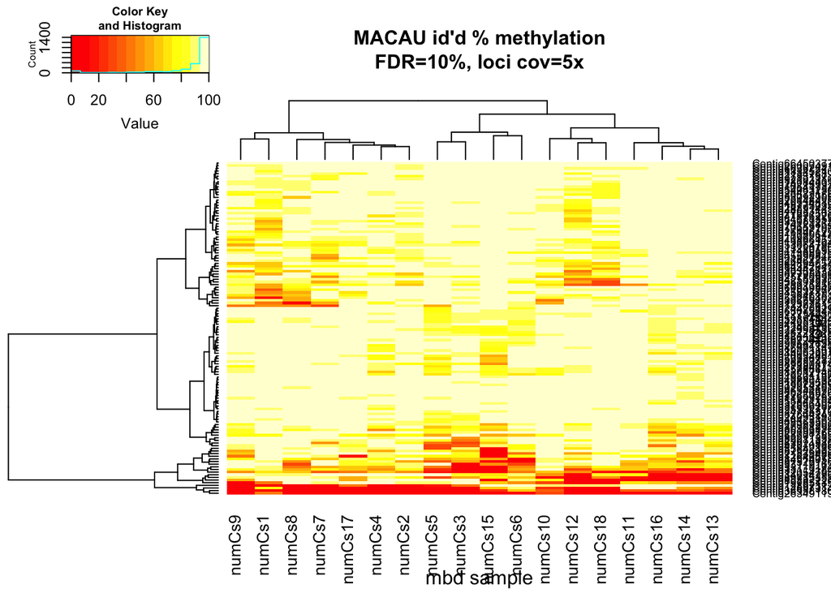

```r
par(cex.main=.8)

heatmap.2(as.matrix(macau.sign.perc.meth.5x[complete.cases(macau.sign.perc.meth.5x[22:39]), 22:39]), main = "MACAU id'd % methylation\nFDR=10%, loci cov=5x", xlab = "mbd sample", ylab = "loci", hclustfun = function(x) hclust(x, method="ward.D"), trace="none")
```

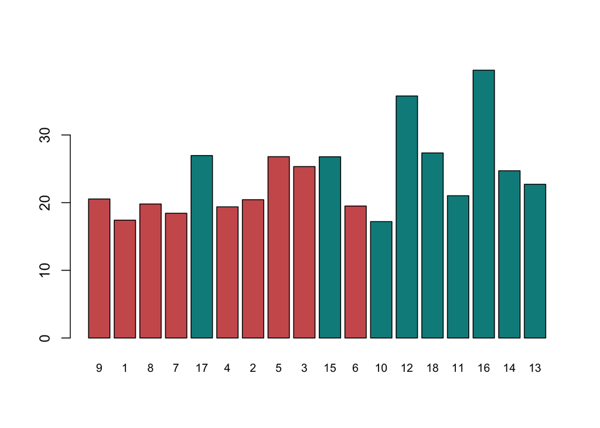

```r
barplot(height = size.macau$y.Length,  names.arg = size.macau$y.MBD.FILENAME, col = mycols[size.macau$pop], cex.names =  0.8)
```

#### PCA with % methylated df, only with loci w/ 5x coverage across all samples

```r
# Transpose methylated count df, remove any loci with NA values (i.e. <5x)
macau.sign.perc.meth.5x.t <- macau.sign.perc.meth.5x[complete.cases(macau.sign.perc.meth.5x[22:39]), c(1,22:39)] %>% remove_rownames %>% gather(column, value, -id) %>% spread(id, value) %>% column_to_rownames(var="column")

# Run PCA on transposed matrix, scale=F creates variance-covariance matrix since all data is same units
met.perc.pca <- prcomp(macau.sign.perc.meth.5x.t, scale=F)
```

#### Inspect PCA axes, etc.

```r
summary(met.perc.pca)
```

```
## Importance of components:
##                            PC1     PC2      PC3      PC4      PC5     PC6
## Standard deviation     94.1089 77.4552 50.09758 49.49142 39.90772 38.6582
## Proportion of Variance  0.3016  0.2043  0.08547  0.08342  0.05424  0.0509
## Cumulative Proportion   0.3016  0.5059  0.59141  0.67483  0.72907  0.7800
##                             PC7     PC8      PC9     PC10     PC11
## Standard deviation     34.67714 31.6874 27.87482 26.49912 24.84154
## Proportion of Variance  0.04095  0.0342  0.02646  0.02391  0.02102
## Cumulative Proportion   0.82092  0.8551  0.88157  0.90549  0.92651
##                            PC12     PC13     PC14    PC15     PC16
## Standard deviation     23.40654 22.55891 19.22050 17.6422 15.31816
## Proportion of Variance  0.01866  0.01733  0.01258  0.0106  0.00799
## Cumulative Proportion   0.94516  0.96250  0.97508  0.9857  0.99367
##                            PC17      PC18
## Standard deviation     13.63573 4.733e-14
## Proportion of Variance  0.00633 0.000e+00
## Cumulative Proportion   1.00000 1.000e+00
```

```r
pca.eigenval(met.perc.pca) #The Proporation of Variance = %variance
```

```
## Importance of components:
```

```
##                                 PC1          PC2          PC3         PC4
## Variance(eigenvalue)   8856.4810357 5999.3080468 2509.7673195 2449.400799
## Proportion of Variance    0.3016207    0.2043154    0.0854739    0.083418
## Cumulative Proportion     0.3016207    0.5059361    0.5914100    0.674828
## Broken-stick value        3.4951081    2.4951081    1.9951081    1.661775
##                                 PC5          PC6          PC7          PC8
## Variance(eigenvalue)   1592.6263290 1494.4571967 1202.5040360 1004.0935670
## Proportion of Variance    0.0542393    0.0508960    0.0409531    0.0341959
## Cumulative Proportion     0.7290673    0.7799633    0.8209164    0.8551123
## Broken-stick value        1.4117747    1.2117747    1.0451081    0.9022509
##                                PC9        PC10        PC11        PC12
## Variance(eigenvalue)   777.0056734 702.2036256 617.1021991 547.8661704
## Proportion of Variance   0.0264621   0.0239146   0.0210163   0.0186584
## Cumulative Proportion    0.8815744   0.9054890   0.9265053   0.9451637
## Broken-stick value       0.7772509   0.6661398   0.5661398   0.4752307
##                               PC13        PC14        PC15        PC16
## Variance(eigenvalue)   508.9044815 369.4276252 311.2455802 234.6461632
## Proportion of Variance   0.0173315   0.0125814   0.0105999   0.0079912
## Cumulative Proportion    0.9624952   0.9750766   0.9856765   0.9936678
## Broken-stick value       0.3918974   0.3149743   0.2435458   0.1768791
##                               PC17      PC18
## Variance(eigenvalue)   185.9330003 0.0000000
## Proportion of Variance   0.0063322 0.0000000
## Cumulative Proportion    1.0000000 1.0000000
## Broken-stick value       0.1143791 0.0555556
```

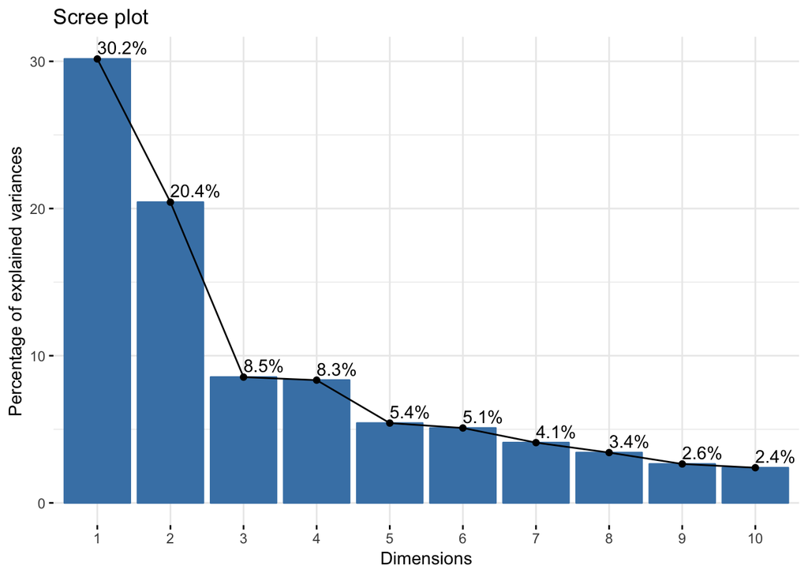

```r
fviz_screeplot(met.perc.pca, addlabels = TRUE) #PC 1, 2 & 3 may be sign.
```

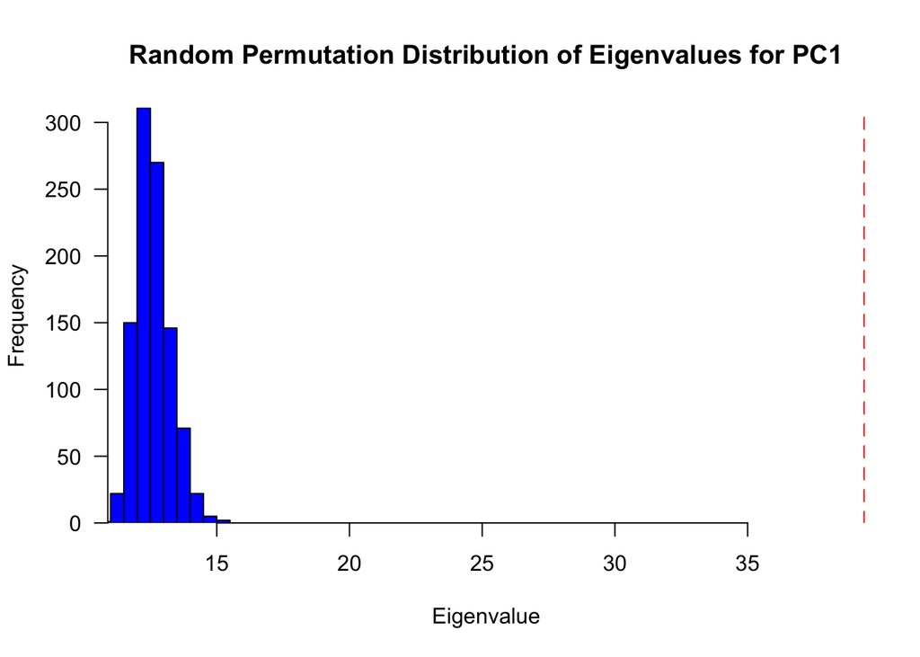

```
## Press return for next plot
```

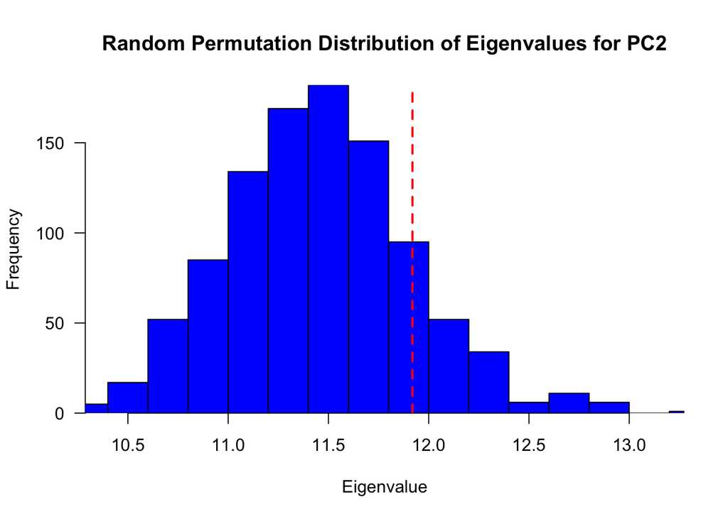

```
## Press return for next plot
```

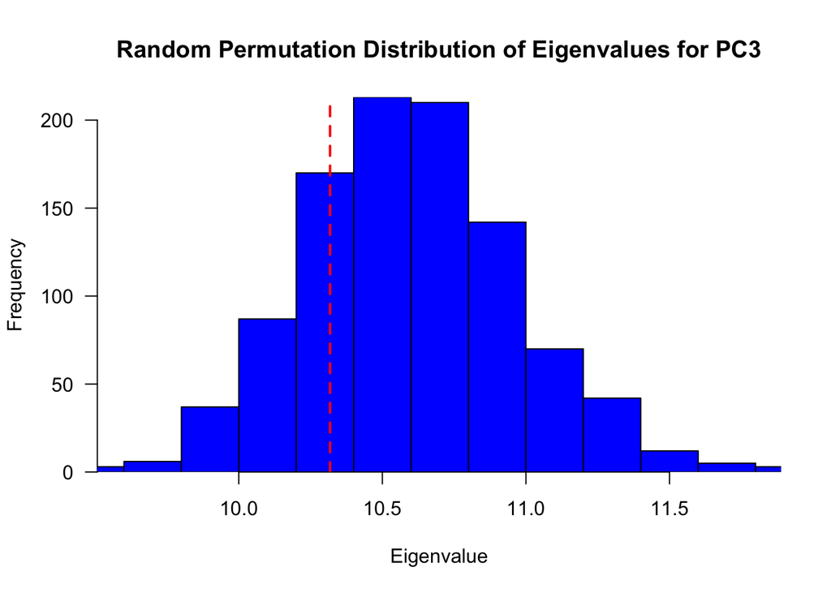

```
## Press return for next plot
```

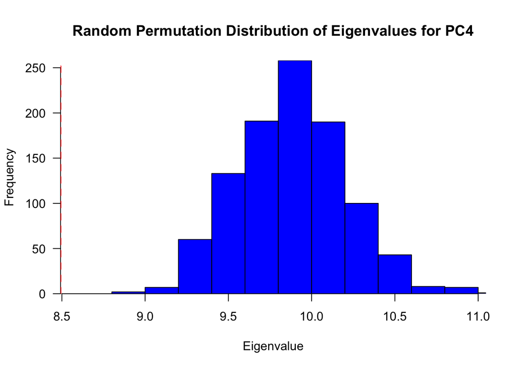

```
## Press return for next plot
```

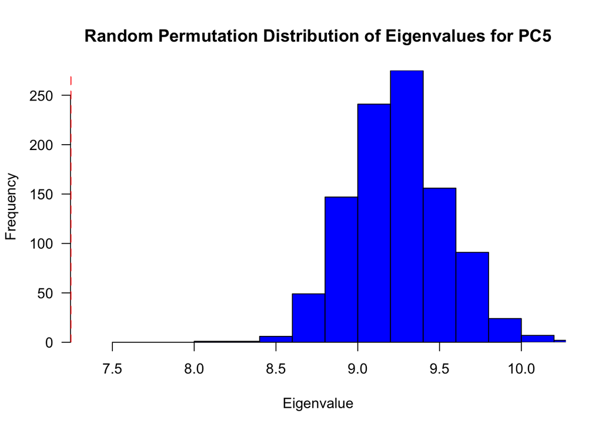

```
## Press return for next plot
## Randomization Test of Eigenvalues:
```

```
##               PC1    PC2    PC3   PC4   PC5
## Eigenvalue 39.413 11.919 10.318 8.492 7.244
## P-value     0.000  0.133  0.792 1.000 1.000
```

```r
ordi.monte(macau.sign.perc.meth.5x.t,ord="pca",dim=5) #only pc 1 sign. according to ordi.monte
```

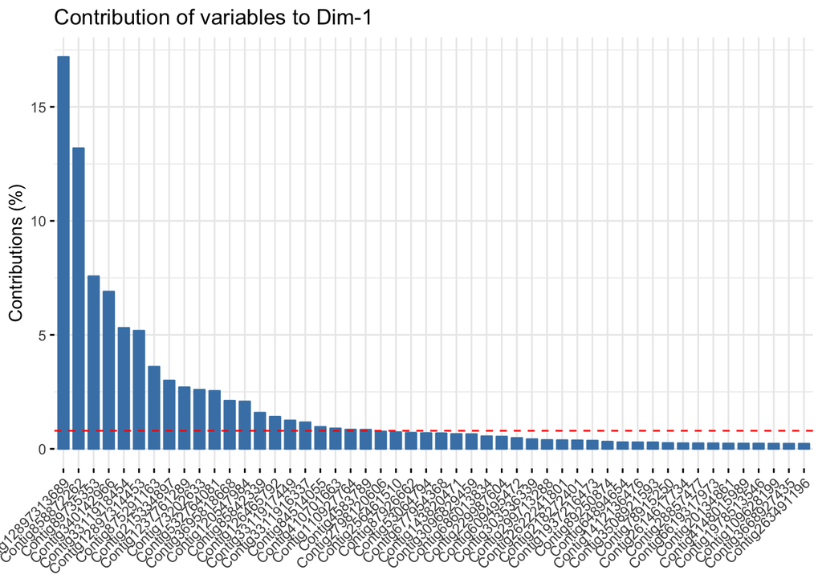

```r
fviz_contrib(met.perc.pca, choice = "var", axes = 1, top=50)
```

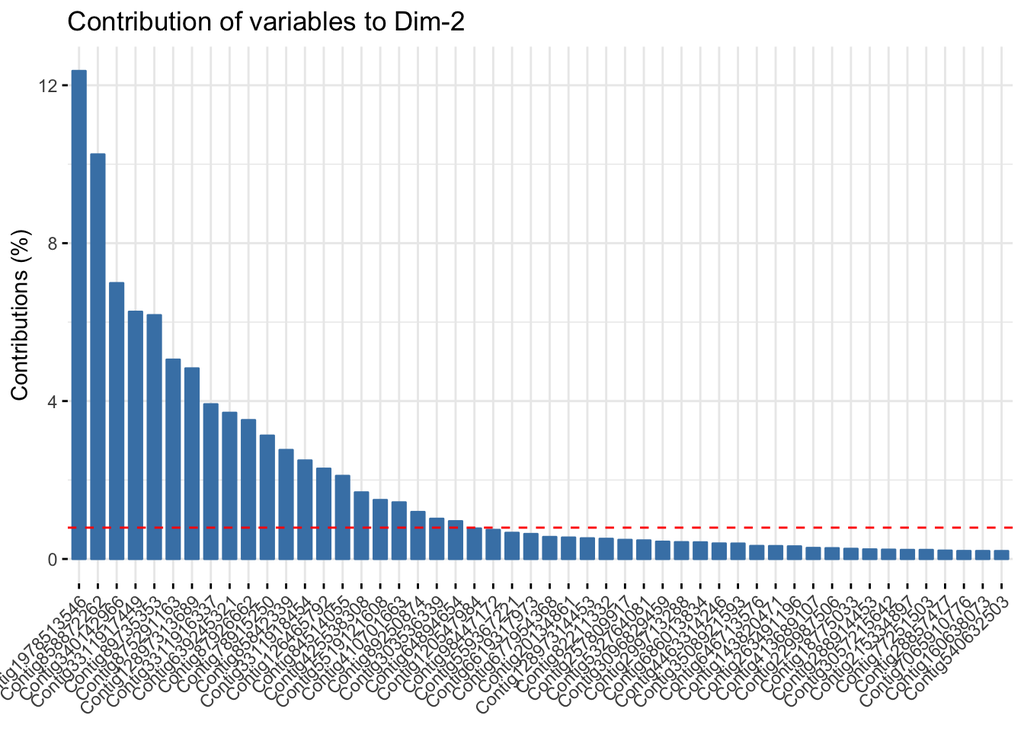

```r
fviz_contrib(met.perc.pca, choice = "var", axes = 2, top=50)
```

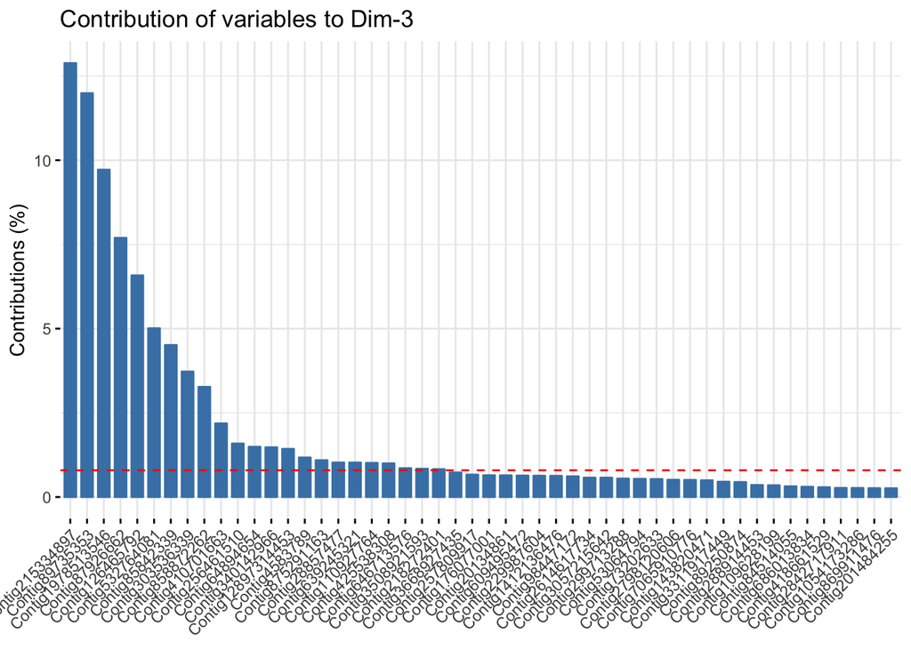

```r
fviz_contrib(met.perc.pca, choice = "var", axes = 3, top=50)
```

#### Create PCA cluster plots (not with variables)

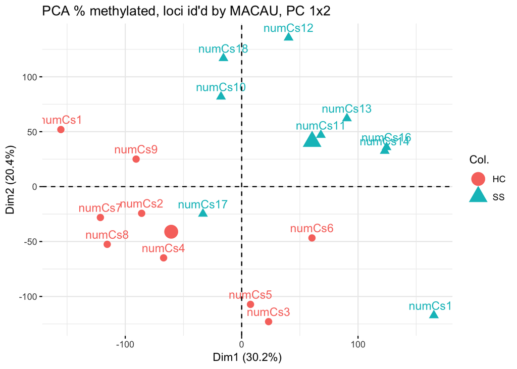

```r
pops <- c("HC", rep("SS", times=9), rep("HC", times=8)) #create pop vector for color-coding

fviz_pca_biplot(met.perc.pca, label="ind", invisible = "var", col.ind=pops, axes = c(1,2), pointsize=3) + ggtitle(label="PCA % methylated, loci id'd by MACAU, PC 1x2")
```

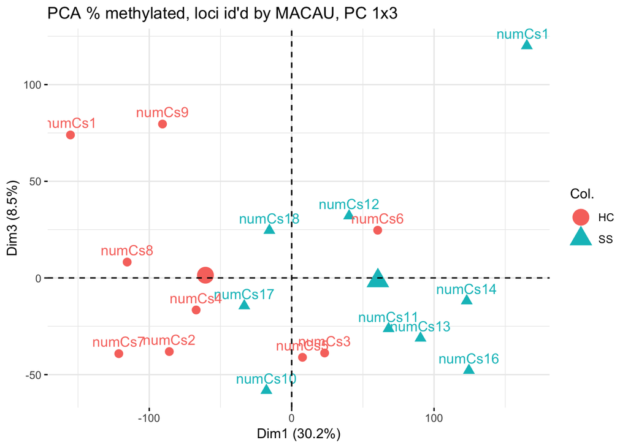

```r
fviz_pca_biplot(met.perc.pca, label="ind",  invisible = "var",col.ind=pops, axes = c(1,3), pointsize=3) + ggtitle(label="PCA % methylated, loci id'd by MACAU, PC 1x3")
```

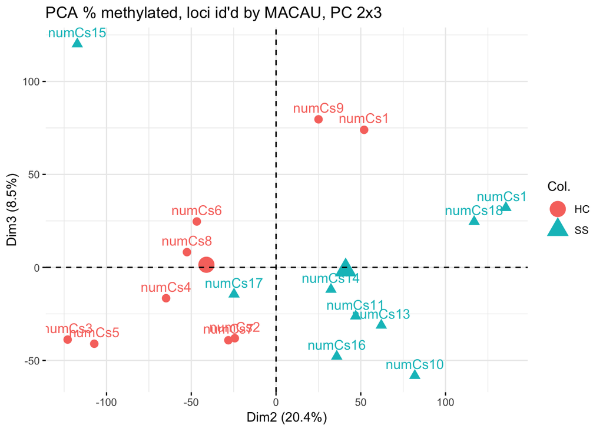

```r
fviz_pca_biplot(met.perc.pca, label="ind", invisible = "var", col.ind=pops, axes = c(2,3), pointsize=3) + ggtitle(label="PCA % methylated, loci id'd by MACAU, PC 2x3")  #dimension 2 = pop separation
```